# D213_Task1

## Part I: Research Question

### A. Describe the purpose of this data analysis by doing the following:

#### 1. Summarize one research question that is relevant to a real-world organizational situation captured in the selected data set and that you will answer using time series modeling techniques.

Can we use time series analysis with this dataset of revenue and days to forecast future revenue?

#### 2. Define the objectives or goals of the data analysis. Ensure that your objectives or goals are reasonable within the scope of the scenario and are represented in the available data.

The goal of this analysis is to look at the relationship between profit over time in order to gain useful insight on revenue in order to forecast future revenue.

## Part II: Method Justification

### B. Summarize the assumptions of a time series model including stationarity and autocorrelated data.

The assumptions of the time series model as are follows:

- The patterns found in the analysis are expected to match future results.
- The data are stationary, meaning that the mean, variance and autocorrelation structure do not change over time. (Nist Sematech Stationarity)
- There are no outliers
- There is no correlated random error.

## Part III: Data Preparation

##### Import Libraries

```python
# import necessary libraries
import numpy as np
import pandas as pd
import matplotlib.pyplot as plt
from functions import *
```

##### Read in Data

```python
# read in data
df = pd.read_csv('teleco_time_series.csv')
df.head()
```

|  | Day | Revenue |
| --- | --- | --- |
| 0 | 1 | 0.000000 |
| 1 | 2 | 0.000793 |
| 2 | 3 | 0.825542 |
| 3 | 4 | 0.320332 |
| 4 | 5 | 1.082554 |

##### Get Data Types

```python
get_dtypes(df)
```

| index | Type |
| --- | --- |
| Day | int64 |
| Revenue | float64 |

##### Convert Day to Datetime

```python
df.set_index('Day',inplace=True)
```

```python
df.index = pd.to_datetime(df.index, unit='D', origin = '2018-12-31')
```

##### Find Null Values

```python
null_vals(df)
```

| index | Null Values |
| --- | --- |
| Revenue | 0 |

### C. Summarize the data cleaning process by doing the following:

#### 1. Provide a line graph visualizing the realization of the time series.

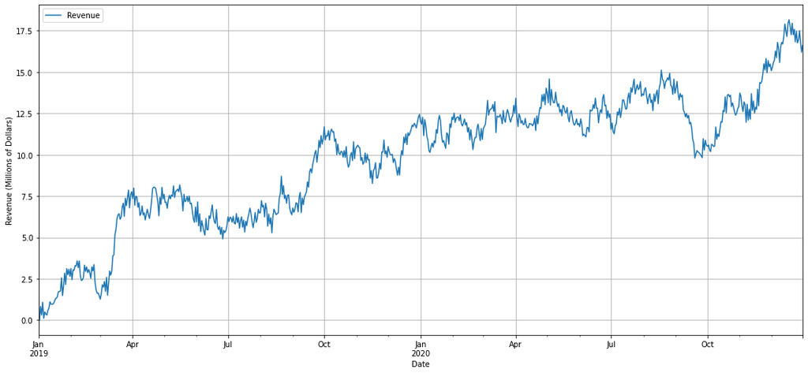

```python
df.plot(grid=True, figsize=(18,8))
plt.xlabel('Date')
plt.ylabel('Revenue (Millions of Dollars)')
plt.show()
```

#### 3. Evaluate the stationarity of the time series.

```python
# Testing Stationarity
from statsmodels.tsa.stattools import adfuller
print("Observations of Dickey-fuller test")
dftest = adfuller(df['Revenue'],autolag='AIC')
dfoutput=pd.Series(dftest[0:4],index=['Test Statistic','p-value','#lags used','number of observations used'])
for key,value in dftest[4].items():
    dfoutput['critical value (%s)'%key]= value
pd.DataFrame(dfoutput, columns=[''])
```

```
Observations of Dickey-fuller test
```

| Test Statistic | -1.924612 |
| --- | --- |
| p-value | 0.320573 |
| #lags used | 1.000000 |
| number of observations used | 729.000000 |
| critical value (1%) | -3.439352 |
| critical value (5%) | -2.865513 |
| critical value (10%) | -2.568886 |

We can see above that your critical values are -3.439352, -2.865513 and -2.568886. Our Test Statistic is -1.924612 meaning that our data is not stationary.

#### 4. Explain the steps used to prepare the data for analysis, including the training and test set split.

Above we checked for null values in the data and found none.

Next the days were made into the index and were converted to datetime from integer datatypes.

Next we will check for any duplicate data.

##### Duplicate Data

```python
get_dupes(df)
```

There are no Duplicate Values

#### Differencing data to make the series stationary

```python
# making it stationary
df_stat = df.diff().dropna()
```

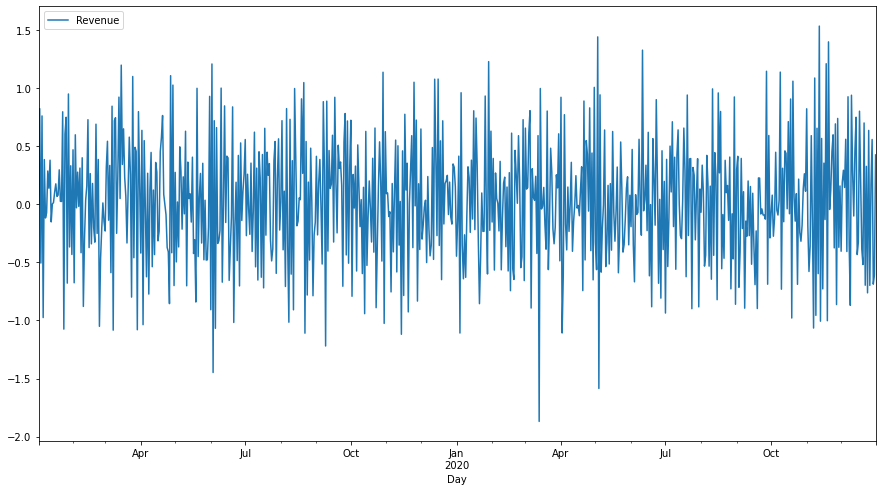

```python
df_stat.plot(figsize=(15,8))
plt.show()
```

```python
# Testing Stationarity
from statsmodels.tsa.stattools import adfuller
print("Observations of Dickey-fuller test")
dftest = adfuller(df_stat['Revenue'],autolag='AIC')
dfoutput=pd.Series(dftest[0:4],index=['Test Statistic','p-value','#lags used','number of observations used'])
for key,value in dftest[4].items():
    dfoutput['critical value (%s)'%key]= value
pd.DataFrame(dfoutput, columns=[''])
```

```
Observations of Dickey-fuller test
```

| Test Statistic | -44.874527 |
| --- | --- |
| p-value | 0.000000 |
| #lags used | 0.000000 |
| number of observations used | 729.000000 |
| critical value (1%) | -3.439352 |
| critical value (5%) | -2.865513 |
| critical value (10%) | -2.568886 |

Above we can see that our test statistic is well below our critical values and so our time series is now stationary.

##### Train Test Split

```python
# split into train/test sets
train, test = df[:365], df[365:]
```

#### 5. Provide a copy of the cleaned dataset.

##### Export a copy of the cleaned dataset.

```python
df_stat.to_csv('D213_T1_Data.csv')
```

## Part IV: Model Identification and Analysis

### D. Analyze the time series dataset by doing the following:

#### 1. Report the annotated findings with visualizations of your data analysis, including the following elements:

```python
# get the decomposition of the time series
from statsmodels.tsa.seasonal import seasonal_decompose
result = seasonal_decompose(df['Revenue'], model='additive', period=1)
```

##### The presence or lack of a seasonal component

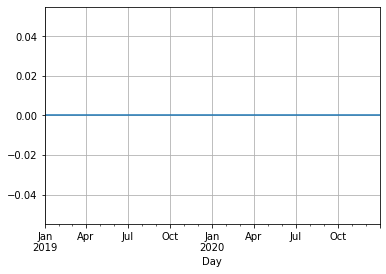

```python
result.seasonal.plot(grid=True)
plt.show()
```

Above we can see that there is no seasonal component to our time series, and so revenue is not dependent on season.

##### Trends

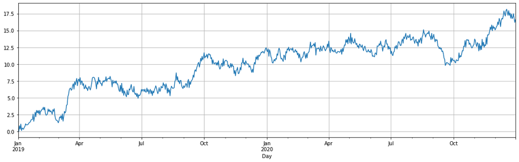

```python
result.trend.plot(grid=True, figsize=(18,5))
plt.show()
```

Above we can see that revenue is trending upward over time.

##### Auto Correlation Function

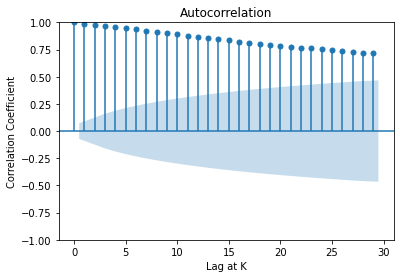

```python
from statsmodels.graphics import tsaplots
fig = tsaplots.plot_acf(df['Revenue'])

plt.xlabel('Lag at K')
plt.ylabel('Correlation Coefficient')
plt.show()
```

In the above autocorrelation plot we can see the strength of the relationship between past and future values. The observations have a positive correlation with recent past observations

##### Spectral Density

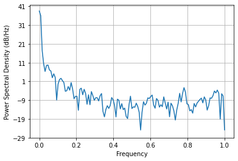

```python
plt.psd(df['Revenue'])
plt.show()
```

Above we can see our spectral density graph representing the frequency domain of the time series

##### The decomposed time series

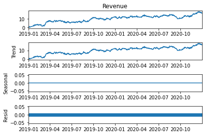

[figure not shown]

```python
# show decomposed time series
result.plot()
```

Above is our decomposed time series

##### Confirmation of the lack of trends in the residuals of the decomposed series

We can see in the last graph in our above decomposition the lack of trends in the residuals.

#### 2. Identify an autoregressive integrated moving average (ARIMA) model that takes into account the observed trend and seasonality of the time series data.

There was no seasonality in this time series and so the ARIMA model with false seasonality was chosen since the lack of seasonlity does not skew this model.

```python
import warnings
warnings.filterwarnings('ignore')
```

```python
from statsmodels.tsa.arima_model import ARIMA
import pmdarima as pm

stepwise_fit = pm.auto_arima(df['Revenue'], start_p=1, start_q=1,
                              test='adf',
                              max_p=3,
                              max_q=3,
                              m=1,
                              d=None,
                              seasonal=False,
                              start_P=0,
                              D=0,
                              trace=True,
                              error_action='ignore',
                              suppress_warnings=True,
                              stepwise=True)
aarima.summary()
```

```
Performing stepwise search to minimize aic
 ARIMA(1,0,1)(0,0,0)[0]             : AIC=1031.213, Time=0.39 sec
 ARIMA(0,0,0)(0,0,0)[0]             : AIC=5521.206, Time=0.03 sec
 ARIMA(1,0,0)(0,0,0)[0]             : AIC=inf, Time=0.25 sec
 ARIMA(0,0,1)(0,0,0)[0]             : AIC=4596.902, Time=0.16 sec
 ARIMA(2,0,1)(0,0,0)[0]             : AIC=996.232, Time=0.55 sec
 ARIMA(2,0,0)(0,0,0)[0]             : AIC=inf, Time=0.50 sec
 ARIMA(3,0,1)(0,0,0)[0]             : AIC=998.227, Time=0.73 sec
 ARIMA(2,0,2)(0,0,0)[0]             : AIC=996.373, Time=0.95 sec
 ARIMA(1,0,2)(0,0,0)[0]             : AIC=996.957, Time=0.54 sec
 ARIMA(3,0,0)(0,0,0)[0]             : AIC=inf, Time=0.54 sec
 ARIMA(3,0,2)(0,0,0)[0]             : AIC=1000.203, Time=0.89 sec
 ARIMA(2,0,1)(0,0,0)[0] intercept   : AIC=997.103, Time=0.82 sec

Best model:  ARIMA(2,0,1)(0,0,0)[0]
Total fit time: 6.356 seconds
```

SARIMAX Results

| Dep. Variable: | y | No. Observations: | 731 |
| --- | --- | --- | --- |
| Model: | SARIMAX(2, 0, 1) | Log Likelihood | -494.116 |
| Date: | Sat, 20 Nov 2021 | AIC | 996.232 |
| Time: | 13:44:54 | BIC | 1014.610 |
| Sample: | 0 | HQIC | 1003.322 |
|  | - 731 |  |  |
| Covariance Type: | opg |  |  |

|  | coef | std err | z | P>\|z\| | [0.025 | 0.975] |
| --- | --- | --- | --- | --- | --- | --- |
| ar.L1 | 0.5189 | 0.068 | 7.621 | 0.000 | 0.385 | 0.652 |
| ar.L2 | 0.4805 | 0.068 | 7.065 | 0.000 | 0.347 | 0.614 |
| ma.L1 | 0.0180 | 0.078 | 0.232 | 0.816 | -0.134 | 0.170 |
| sigma2 | 0.2242 | 0.013 | 17.762 | 0.000 | 0.199 | 0.249 |

| Ljung-Box (L1) (Q): | 0.02 | Jarque-Bera (JB): | 2.04 |
| --- | --- | --- | --- |
| Prob(Q): | 0.88 | Prob(JB): | 0.36 |
| Heteroskedasticity (H): | 1.03 | Skew: | -0.02 |
| Prob(H) (two-sided): | 0.82 | Kurtosis: | 2.74 |

Warnings:  
[1] Covariance matrix calculated using the outer product of gradients (complex-step).

Above, our best model is SARIMAX(2, 0, 1)

#### 3. Perform a forecast using the derived ARIMA model.

##### Predictions on testing dataset

```python
# Arima Model
from statsmodels.tsa.arima.model import ARIMA
from statsmodels.tsa.statespace.sarimax import SARIMAX
model = SARIMAX(train['Revenue'], order=(2,0,1)).fit()
model.summary()
```

SARIMAX Results

| Dep. Variable: | Revenue | No. Observations: | 365 |
| --- | --- | --- | --- |
| Model: | SARIMAX(2, 0, 1) | Log Likelihood | -243.917 |
| Date: | Sat, 20 Nov 2021 | AIC | 495.833 |
| Time: | 13:44:55 | BIC | 511.433 |
| Sample: | 01-01-2019 | HQIC | 502.033 |
|  | - 12-31-2019 |  |  |
| Covariance Type: | opg |  |  |

|  | coef | std err | z | P>\|z\| | [0.025 | 0.975] |
| --- | --- | --- | --- | --- | --- | --- |
| ar.L1 | 0.4499 | 0.088 | 5.121 | 0.000 | 0.278 | 0.622 |
| ar.L2 | 0.5489 | 0.088 | 6.258 | 0.000 | 0.377 | 0.721 |
| ma.L1 | 0.0994 | 0.104 | 0.959 | 0.337 | -0.104 | 0.303 |
| sigma2 | 0.2192 | 0.018 | 12.048 | 0.000 | 0.184 | 0.255 |

| Ljung-Box (L1) (Q): | 0.03 | Jarque-Bera (JB): | 1.81 |
| --- | --- | --- | --- |
| Prob(Q): | 0.86 | Prob(JB): | 0.41 |
| Heteroskedasticity (H): | 0.90 | Skew: | -0.01 |
| Prob(H) (two-sided): | 0.55 | Kurtosis: | 2.66 |

Warnings:  
[1] Covariance matrix calculated using the outer product of gradients (complex-step).

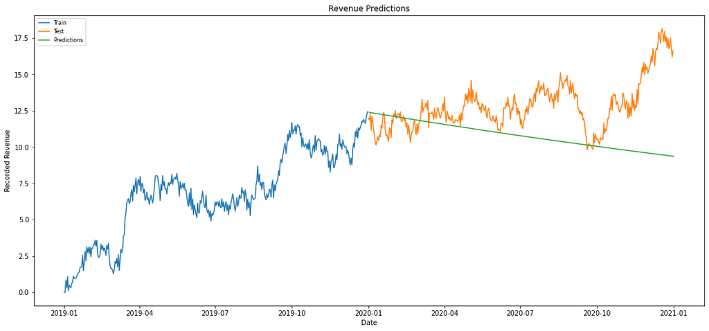

```python
start = len(train) + 1
end = len(df)

# Predict with respect to test set
predictions = model.predict(start, end, type='levels')
plt.figure(figsize=(18,8))
plt.plot(train, label = 'Train')
plt.plot(test, label = 'Test')
plt.plot(predictions, label = 'Predictions')
plt.title('Revenue Predictions')
plt.xlabel('Date')
plt.ylabel('Recorded Revenue')
plt.legend(loc='upper left', fontsize = 8)
plt.show()
```

```python
# Arima Model
from statsmodels.tsa.arima.model import ARIMA
from statsmodels.tsa.statespace.sarimax import SARIMAX
model = SARIMAX(df['Revenue'], order=(2,0,1)).fit()
model.summary()
```

SARIMAX Results

| Dep. Variable: | Revenue | No. Observations: | 731 |
| --- | --- | --- | --- |
| Model: | SARIMAX(2, 0, 1) | Log Likelihood | -494.116 |
| Date: | Sat, 20 Nov 2021 | AIC | 996.232 |
| Time: | 13:44:56 | BIC | 1014.610 |
| Sample: | 01-01-2019 | HQIC | 1003.322 |
|  | - 12-31-2020 |  |  |
| Covariance Type: | opg |  |  |

|  | coef | std err | z | P>\|z\| | [0.025 | 0.975] |
| --- | --- | --- | --- | --- | --- | --- |
| ar.L1 | 0.5189 | 0.068 | 7.621 | 0.000 | 0.385 | 0.652 |
| ar.L2 | 0.4805 | 0.068 | 7.065 | 0.000 | 0.347 | 0.614 |
| ma.L1 | 0.0180 | 0.078 | 0.232 | 0.816 | -0.134 | 0.170 |
| sigma2 | 0.2242 | 0.013 | 17.762 | 0.000 | 0.199 | 0.249 |

| Ljung-Box (L1) (Q): | 0.02 | Jarque-Bera (JB): | 2.04 |
| --- | --- | --- | --- |
| Prob(Q): | 0.88 | Prob(JB): | 0.36 |
| Heteroskedasticity (H): | 1.03 | Skew: | -0.02 |
| Prob(H) (two-sided): | 0.82 | Kurtosis: | 2.74 |

Warnings:  
[1] Covariance matrix calculated using the outer product of gradients (complex-step).

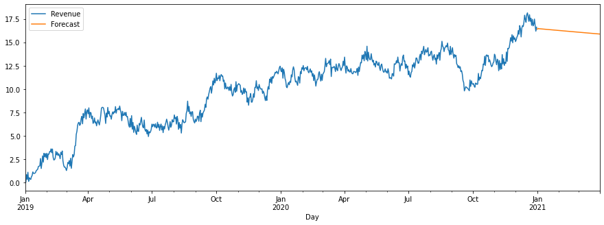

```python
# forecast vs actual plot
forecast = model.forecast(90).rename('Forecast')
df['Revenue'].plot(figsize = (15, 5), legend = True)
forecast.plot(legend = True)
plt.show()
```

#### 4. Provide the output and calculations of the analysis you performed.

```python
from sklearn.metrics import mean_squared_error
from statsmodels.tools.eval_measures import rmse

# Run Mean Squared Error
MSE = mean_squared_error(test['Revenue'], predictions)
RMSE = rmse(test['Revenue'], predictions)
pd.DataFrame(zip(['MSE:', 'RMSE:'], [MSE, RMSE]), columns=['', ' ']).set_index('')
```

| MSE: | 9.398028 |
| --- | --- |
| RMSE: | 3.065620 |

#### 5. Provide the code used to support the implementation of the time series model.

The code is provided above.

## Part V: Data Summary and Implications

### E. Summarize your findings and assumptions, including the following points:

#### 1. Discuss the results of your data analysis, including the following:

- the selection of an ARIMA model

- the prediction interval of the forecast

The prediction interval is one day.

- a justification of the forecast length

This model bases it's predictions off of recent past predictions and expects that trend to be followed, and so making longer predictions may be inaccurate.

- the model evaluation procedure and error metric

The mean squared error for this model is 9.398028, The RMSE is 3.065620

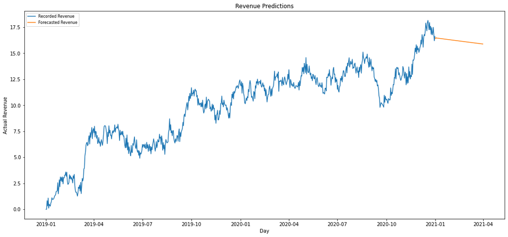

```python
# Predict with respect to test set
predictions = model.forecast(90)
plt.figure(figsize=(18,8))
plt.plot(df['Revenue'], label = 'Recorded Revenue')
plt.plot(predictions, label = 'Forecasted Revenue')
plt.title('Revenue Predictions')
plt.xlabel('Day')
plt.ylabel('Actual Revenue')
plt.legend(loc='upper left', fontsize = 8)
plt.show()
```

#### 3. Recommend a course of action based on your results.

Based on these results I would recommend analyzing the reasoing behind the periodic dips in revenue, and the reasoning between the periodic spikes. It looks like the company is about to experience another small dip, and so it would be appropriate to try and mitigate this result as best as possible by identifying the underlying causes.

## Part VI: Reporting

### F. Create your report from part E using an industry-relevant interactive development environment (e.g., an R Markdown document, a Jupyter Notebook, etc.). Include a PDF or HTML document of your executed notebook presentation.

### G. List the web sources used to acquire data or segments of third-party code to support the application.

“Stationarity: What Is Stationarity: Checking Stationarity in Python.” Analytics Vidhya, 26 Apr. 2021, https://www.analyticsvidhya.com/blog/2021/04/how-to-check-stationarity-of-data-in-python/.

Prabhakaran, Selva. “Arima Model - Complete Guide to Time Series Forecasting in Python: ML+.” Machine Learning Plus, 14 Nov. 2021, https://www.machinelearningplus.com/time-series/arima-model-time-series-forecasting-python/.

### H. Acknowledge sources, using in-text citations and references, for content that is quoted, paraphrased, or summarized.

“Stationarity.” 6.4.4.2. Stationarity, https://www.itl.nist.gov/div898/handbook/pmc/section4/pmc442.htm#:~:text=A%20common%20assumption%20in%20many,do%20not%20change%20over%20time.